# 数据类型，运算，逻辑和函数

## 数据类型 (Data Classes)

R没有标量，它通过各种类型的向量 (vector)来存储数据。常用的数据类型有：

| 类型 | 含义与说明 | 例子 |
| --- | --- | --- |
| numeric | 浮点数向量 | `3`, `0.5`, `sqrt(2)`, `NaN` |
| integer | 整数向量 | `3L`, `100L` |
| character | 字符向量；需被引号包围 | `"1"`, `"$"`, `"你好"` |
| logical | 逻辑向量 | `TRUE`, `FALSE`, `NA` |
| complex | 复数向量 | `3+5i`, `1i`, `1+0i` |

| xxx | 描述 | xxx |
| --- | --- | --- |
| factor | 因子，用于标记样本 |  |

通过`class`函数，可以查看指定数据的类型。

## 运算

### 基础

#### 基础中的基础（加减乘除）

最基础的arithmetic operators（数学运算符）有：

| 符号 | 描述 |
| --- | --- |
| `+` | 加 |
| `-` | 减 |
| `*` | 乘 |
| `/` | 除以 |
| `^`或`**` | 乘幂 |

以上这些应该不需要解释。

#### 科学计数法

R可以使用科学计数法(`AeB`$= A \times 10^B$)，比如：

```r
3.1e5
```

```
## [1] 310000
```

```r
-1.2e-4+1.1e-5
```

```
## [1] -0.000109
```

#### 求整数商和余数

`%%` 是求余数符号，比如7%%3得到1；

`%/%` 是求整数商，比如7%%3得到2；

最常见的两个用法是判定一个数的奇偶性，和时间，角度等单位的转换。（后面再详细介绍）。

#### 对数

`log(x, base=y)`便是运算$\log_y{x}$，或者写成 `log(base=y, x)`也可以;

它可以简写成`log(x,y)`，同样表示的是$\log_y{x}$，但是如果写成`log(y,x)`就变成了$\log_x{y}$

如果你有一点编程基础，应该能看明白为什么，如果没看明白，下面讲函数的时候我会解释。

## 逻辑

### Logical Operators（逻辑运算符）

R中的logical operators 有：

| 符号 | 描述 |
| --- | --- |
| `==` | equal to（等于） |
| `!=` | equal to（不等于） |
| `<` | less than（小于） |
| `>` | more than（大于） |
| `<=` | less than or equal to（小于等于） |
| `>=` | more than or equal to（大于等于） |
| `&` | AND（和） |
| `\|` | OR（或） |
| `!` | 反义符号（见下） |

## 以下是不重要的一些内容

### Console和R script编辑器的一些特性

Console 中每个命令开头的`>`叫做prompt（我不知道它的中文名诶），当它出现在你所编辑的那一行的开头时，按下回车的时候那行的命令才会被执行。有时候它会消失，这时候按`esc`可以将其恢复。

prompt消失的主要原因是你的代码没有写完，比如括号不完整：

```
> 2+(3+4
```

这时你按回车，它会显示：

```
> 2+(3+4
+
```

`+`号是在提示代码没写完整。这时你把括号补上再按回车：

```
> 2+(3+4
+ )
```

```
[1] 9
```

便可以完成计算。

这意味着我们可以把一条很长的命令分成很多行。比如我们可以写这样的代码（在R script编辑器中！）

```r
if(1 + 1 == 2 & 1 + 2 == 5){
  print(2)
} else{
  print(3)
}
```

然后`Ctrl`+`Enter`执行。

[output not shown]

## 函数

不像很多其他语言的函数有`value.func()`和`func argument`等格式，R中所有函数的通用格式是这样的：

```
function(argument1=value1, argument2=value2)
```

比如

```r
x1 <- c(5.1,5.2,4.5,5.3,4.3,5.5,5.7)
t.test(x = x1, mu = 4.5)
```

```
##
##  One Sample t-test
##
## data:  x1
## t = 3.0308, df = 6, p-value = 0.02307
## alternative hypothesis: true mean is not equal to 4.5
## 95 percent confidence interval:
##  4.612840 5.558589
## sample estimates:
## mean of x
##  5.085714
```

## 简易的统计学计算

### t分布

下面介绍的这几种方法是以这个t分布函数图为基础的：

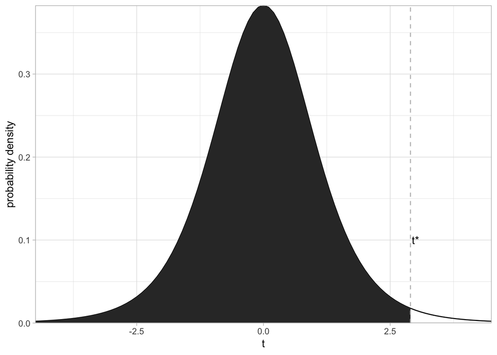

阴影区域为$P$，虚线对应的$t$为$t^*$. `qt()`可以把$P$转化成$t^*$,`pt()`则相反。

举个例子就明白了。假设你需要算一个confidence interval（置信区间），confidence level（置信等级）为$95\%$，即$\alpha=0.05$，degrees of freedom(自由度)为$12$，那么怎么算$t^*$呢？

```r
qt(0.975, df = 12)
```

```
## [1] 2.178813
```

```r
p <- (1-(pt(2.2, df = 15)))*2
p
```

```
## [1] 0.04389558
```

其中`pt(2.2, df = 15)`算出阴影面积，1减去它再乘以二就是对应的双尾t检验的$p$值。

### z分布

没有z分布专门的函数。可以直接用t分布代替，把`df`调到很大（比如`999999`）就行了。比如我们试一下$95\%$置信区间所对应的$z$：

```r
qt(0.975,9999999)
```

```
## [1] 1.959964
```

（果然是$1.96$）

### t检验

t test分为以下几种：

- One sample t test
- Two sample…
  - paired t test
  - Unequal variance t test
  - Equal variance t test

在R中做t检验，很简单，以上这些t检验，都是用`t.test` 这个函数去完成。

以one sample为例：

```r
x <- c(2.23,2.24,2.34,2.31,2.35,2.27,2.29,2.26,2.25,2.21,2.29,2.34,2.32)
t.test(x, mu = 2.31)
```

```
##
##  One Sample t-test
##
## data:  x
## t = -2.0083, df = 12, p-value = 0.06766
## alternative hypothesis: true mean is not equal to 2.31
## 95 percent confidence interval:
##  2.257076 2.312155
## sample estimates:
## mean of x
##  2.284615
```

可以看到$p=0.06766$。

R的默认是双尾检验，你也可以设置成单尾的：

```r
x <- c(2.23,2.24,2.34,2.31,2.35,2.27,2.29,2.26,2.25,2.21,2.29,2.34,2.32)

t.test(x, mu = 2.31, alternative = "less")
```

```
##
##  One Sample t-test
##
## data:  x
## t = -2.0083, df = 12, p-value = 0.03383
## alternative hypothesis: true mean is less than 2.31
## 95 percent confidence interval:
##      -Inf 2.307143
## sample estimates:
## mean of x
##  2.284615
```

$p$值一下就减了一半。

Two-sample:

```r
x <- c(2.23,2.24,2.34,2.31,2.35,2.27,2.29,2.26,2.25,2.21,2.29,2.34,2.32)
y <- c(2.27,2.29,2.37,2.38,2.39,2.25,2.39,2.16,2.55,2.81,2.19,2.44,2.22)

t.test(x, y)
```

```
##
##  Welch Two Sample t-test
##
## data:  x and y
## t = -1.5624, df = 13.65, p-value = 0.1411
## alternative hypothesis: true difference in means is not equal to 0
## 95 percent confidence interval:
##  -0.18460351  0.02921889
## sample estimates:
## mean of x mean of y
##  2.284615  2.362308
```

r的默认是non-paired, unequal variance，你可以通过增加`paired = TRUE`，`var.equal = TRUE`这两个参数来改变它。

```r
t.test(x, y, paired = TRUE)
```

```
##
##  Paired t-test
##
## data:  x and y
## t = -1.4739, df = 12, p-value = 0.1662
## alternative hypothesis: true difference in means is not equal to 0
## 95 percent confidence interval:
##  -0.19253874  0.03715412
## sample estimates:
## mean of the differences
##             -0.07769231
```